# How can companies assess which customers qualify for credit approval?

# Framing the problem

## 1. Problem recognition

To date, payment in monthly installments is a type of payment often customers look for whenever they purchase items especially the high-priced ones. This is where credit/lending programs play an important role in profitability of any banks and financial services industries. While this sounds beneficial, it’s not always the case since it still depends on how an institution evaluates their customers’ credits.

This being considered, failure to assess accurately the merit of an individual applying for a loan can lead to 2 possible scenarios: granting a credit to a person with a higher risk than desirable or not granting a credit to a person with more than acceptable credit risk.

**How can companies assess which customers qualify for credit approval?**

Our dataset contains 1000 observations provided by Professor Dr. Hans Hofmann, at Institut für Statistik und “Okonometrie Universit” at Hamburg University (source). It describes people using a set of attributes and assign them a ‘good’ or ‘bad’ credit risk.

Such task was historically performed through human judgment, is it still the case? Are algorithms accurate enough to become fully entitled to make a decision?

## 2. Review of Previous findings

### 2.1 Key insights

With the trend of e-commerce industry where companies like eBay, Amazon and Walmart <sup>[1]</sup> get to have big market share is brought about by providing convenient ways of payments options to their customers, allowing them to pay in monthly basis instead of one-time payment. However, there are still some known consumer goods companies that do not offer the possibility to purchase their items through monthly payments.

According to a research released in November 2018 by Citizens Bank<sup>[3]</sup>,

> “76% of U.S. consumers are more likely to make a retail purchase if a payment plan backed by a simple and seamless point of sale experience is offered. Therefore, if a company wants to maximize the sales of its products it is important to provide a payment plan in installments.” There are fundamentally 2 ways to offer a payment in installments:
> - Offering the service at the check-out through an accredited financial services company (e.g. Ebay with ‘PayPal Credit’)
> - Providing the service using the company’s own brand, issuance of the credit and credit cards with a partner (e.g. Amazon with ‘Amazon Store Card’ issued by Synchrony Bank)

In any case, if a company choose to provide such service, **it needs data to evaluate whether a customer is worthy or not to receive the credit. This kind of information can be gathered directly upon users’ registration and just by browsing the website, both externally or at the checkout section.**

However, the application for the payment in monthly installments must be simple and seamless to be effective, hence data collection in-store might not be a convenient way to consider.  
In the long term, [‘The Future of Credit’ 2018 Deloitte’s](https://www2.deloitte.com/content/dam/Deloitte/uk/Documents/financial-services/deloitte-uk-mastercard-the-future-of-credit-a-european-perspective-2019-report-digital-updated.pdf) Report predicts consumer spending to rise together with growth in credit demand. However, this trend has been slowed down by the Covid-19 global pandemic. As we can see in Graph. 1, after the economic crisis in 2008 the consumer credit change has been negative for approximately 5 years.

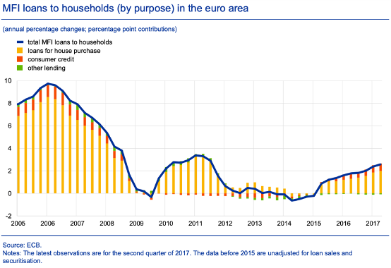

[Graph.1 source](https://www.ecb.europa.eu/pub/pdf/other/ebbox201707_03.en.pdf?ad68ed4b5b551c5f4472b36bb12d5525)

Probably, this is due to the combination of 2 effects:

- Due to the economic recession, consumers have less money to spend
- Consumers tend to have less confidence in their present and future financial situation and, as a result, they are more conservative.

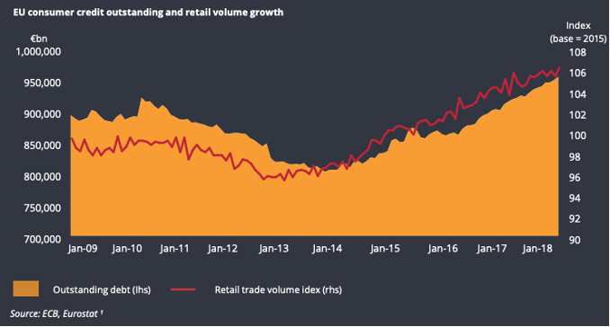

[Graph.2 source](https://www2.deloitte.com/content/dam/Deloitte/uk/Documents/financial-services/deloitte-uk-mastercard-the-future-of-credit-a-european-perspective-2019-report-digital-updated.pdf)

As expected, in Graph. 3 we can see that the consumer confidence has declined during the period of post-crisis (2008-2014).

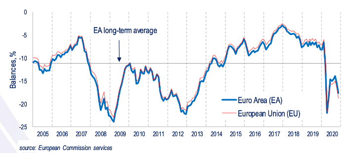

[Graph.3 source](https://ec.europa.eu/info/sites/info/files/flash_consumers_2020_11_en.pdf)

In conclusion, we might expect an unfavorable movement in consumer credit in the coming years due to the economic recession and due to consumers’ confidence that was triggered by the current pandemic. Despite this however, since consumer spending is expected to rise and since consumer credit is positively correlated with expenditures, this may prompt consumer credit to spike as well.

Finally, since the consumer credit is shifting towards to the B2C e-commerce market, this may give a competitive advantage to e-commerce (like Amazon US) that give the possibility to customers to buy their products with monthly installations. Therefore, it is becoming particularly important for all the companies that want to maximize the sales, especially on their ecommerce, to provide a simple and seamless service of consumer credit.

#### Sources

- Amazon.com, ebay.com, Walmart.com
- https://www.economist.com/free-exchange/2008/10/20/night-of-the-living-debt
- https://www.businesswire.com/news/home/20181108005056/en/76-Of-Consumers-Are-More-Likely-to-Make-a-Purchase-If-a-Simple-and-Seamless-Payment-Plan-is-Offered

### 2.2 Defining the Hypothesis

Using data about customers asking for a consumer credit we expect to create a model able to predict with reliable accuracy if the company should grant the credit or not. Namely, classifying the customers as:

- 0 = Good
- 1 = Bad

When making a binary classification, as in our case, we have two classes (Good or Bad) there 4 possible outcomes:

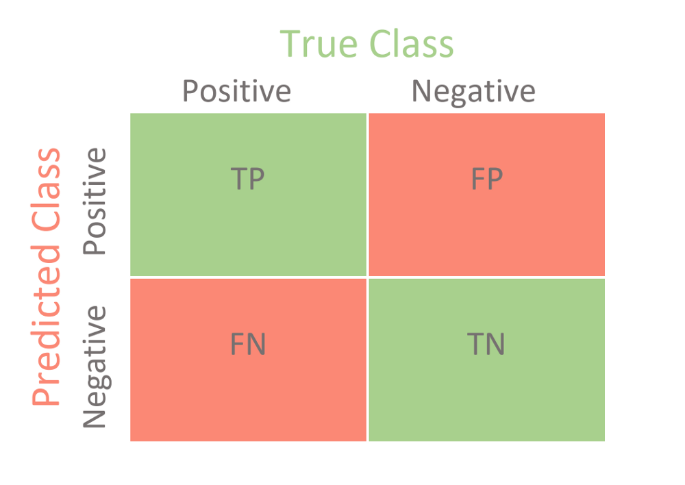

[source](https://towardsdatascience.com/confusion-matrix-for-your-multi-class-machine-learning-model-ff9aa3bf7826)

#### 2.2.1. Research Design

In this research, the `Binary Logistic Regression Model` – a type of logistic regression that is commonly used to predict the relationship between predictors and a dependent variable where this variable is `dichotomous` (e.g., Gender [Female vs Male], acceptance [Yes or No]). In our case, the dependent variable is the “Credit Risk”. This estimates the probability that the dependent variable belongs to a particular category. source: https://www.statisticssolutions.com/what-is-logistic-regression/

For example:

Pr(Credit Risk = Good|with credits existing in other banks)

To explain the conditional statement above, it simply say that the value of Pr(Credit Risk = Good|with credits existing in other banks) will range between 0 and 1 and for any given value of other existing credits, a prediction can be concluded for its credit risk.

$${logit}(\pi_i)=log\frac{p(X)}{1−p(X)}={\beta_0}+{\beta_1x}...+{\beta_nx}$$

## Solving the Problem

#### Setting up packages

Loading the packages we are going to use throughout the analysis

```r
# Library containing useful methods to manipulate tables
library(tidyverse)
library(modelr)
library(broom)
library(dplyr)
# Library to build correlation plots
library(corrplot)
library(Hmisc)
library(forcats)
library(RColorBrewer)
library(caret)
library(ROCR)

# Library for stepwise regressions
# install.packages("leaps")
library(leaps)
```

## 1 Data and Variable Selection

### 1.1 importing the dataset

The raw data file contains 1000 observations of 21 variables. Each observation refers to a customer and every customer’ credit risk is classified as good or bad. These 21 attributes are used to evaluate loan applications.

```r
# Load the dataset from the .csv file
df_raw_german_credit <- read.csv("german_data.csv", stringsAsFactors=FALSE, fileEncoding="latin1")
# Save the dataset as a Table
tbl_german_credit <- as_tibble(df_raw_german_credit)
```

To increase clarity of the meaning of the variables and reduce the lenght of the variables in some cases we changed the column names.

```r
# Create a vector with new column names
v_updated_colnames <- c("Account_Balance",  "Duration_of_Credit",  "Status_Prev_Credits",  "Purpose",  "Credit_Amount",  "Savings",  "Employment_Duration",  "Installment_Rate",  "Sex_Marital_Status",  "Guarantors",  "Residence_Years",  "Assets",  "Age",  "Concurrent_Credits",  "Housing",  "Existing_Credits",  "Job",  "N_Dependents",  "Telephone",  "Foreign_Worker",  "Credit_Risk")
# Update column names
colnames(tbl_german_credit) <- v_updated_colnames
# Save the table into newly create table for later use
tbl_german_credit_num <- tbl_german_credit
```

The categorical variables’ values have been encoded using categorical/symbolic attributes.

```r
# Dispaly the first 5 rows of the dataset
head(tbl_german_credit,5)
```

```
## # A tibble: 5 x 21
##   Account_Balance Duration_of_Cre… Status_Prev_Cre… Purpose Credit_Amount
##   <chr>                      <int> <chr>            <chr>           <int>
## 1 A11                            6 A34              A43              1169
## 2 A12                           48 A32              A43              5951
## 3 A14                           12 A34              A46              2096
## 4 A11                           42 A32              A42              7882
## 5 A11                           24 A33              A40              4870
## # … with 16 more variables: Savings <chr>, Employment_Duration <chr>,
## #   Installment_Rate <int>, Sex_Marital_Status <chr>, Guarantors <chr>,
## #   Residence_Years <int>, Assets <chr>, Age <int>, Concurrent_Credits <chr>,
## #   Housing <chr>, Existing_Credits <int>, Job <chr>, N_Dependents <int>,
## #   Telephone <chr>, Foreign_Worker <chr>, Credit_Risk <int>
```

Since the dataset comes with a legend, explaining what each code means, we have transformed the symbolic values to their respective categorical values For example, all the column Purpose has the following legend:

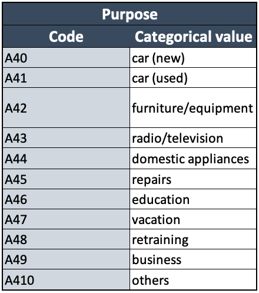

In this case all the “A40” have been transformed to “car (new)”, all the “A41” have been transformed to “car (used)”, and so on.

To apply such transformation, we created a decoding matrix for each categorical variable.

```r
### Define the decoding matrices for each categorical variable ###
df_decod_Account_Balance <- data.frame(c("A11", "A12","A13","A14"),c("x < 0" , "0 <= x < 200", "x >=200", "no checking account"),c(3,2,1,4))
df_decod_Status_Prev_Credits <- data.frame(c("A30","A31","A32","A33","A34"),c("no credits taken/all credits paid" , "all credits at this bank paid", "existing credits paid", "delay in paying off","critical account/other credits existing (not at this bank)"),c(1,2,3,4,5))
df_decod_Purpose <- data.frame(c("A40","A41","A42","A43","A44","A45","A46","A47","A48","A49","A410"),c("car (new)" , "car (used)", "furniture/equipment", "radio/television","domestic appliances", "repairs", "education","vacation", "retraining", "business", "other"))
df_decod_Savings <- data.frame(c("A61","A62","A63","A64","A65"), c("x < 100" , "100 <= x < 500", "500 <= x < 1000", "x >= 1000","unkown/no savings account"),c(2,3,4,5,1))
df_decod_Employment_Duration <- data.frame(c("A71","A72","A73","A74","A75"), c("unemployed","x < 1" , "1 <= x < 4", "4 <= x < 7", "x >= 7"),c(1,2,3,4,5))
df_decod_Sex_Marital_Status <- data.frame(c("A91","A92","A93","A94","A95"), c("male divorced/separated" , "female divorced/separated", "male single", "male married/widowed", "female single"))
df_decod_Guarantors <- data.frame(c("A101","A102","A103"), c("none" , "co-applicant", "guarantor"),c(1,2,3))
df_decod_Assets <- data.frame(c("A121","A122","A123","A124"), c("real estate" , "life insurance", "car", "no property"),c(4,3,2,1))
df_decod_Concurrent_Credits <- data.frame(c("A141","A142","A143"), c("bank" , "stores", "none"))
df_decod_Housing <- data.frame(c("A151","A152","A153"), c("rent" , "own", "for free"),c(1,2,3))
df_decod_Job <- data.frame(c("A171","A172","A173","A174"), c("unemployed/unskilled - non-resident" , "unskilled - resident", "skilled employee / official", "management / self-employed / highly qualified employee / officer"), c(1,2,3,4))
df_decod_Telephone <- data.frame(c("A191","A192"), c("no" , "yes"), c(1,2))
df_decod_Foreign_Worker <- data.frame(c("A201","A202"), c("yes" , "no"), c(1,2))
# Create a list containing all the decoding matrices
l_decod_matrices <- list(df_decod_Account_Balance, df_decod_Status_Prev_Credits, df_decod_Purpose, df_decod_Savings, df_decod_Employment_Duration, df_decod_Sex_Marital_Status , df_decod_Guarantors, df_decod_Assets,  df_decod_Concurrent_Credits,  df_decod_Housing, df_decod_Job, df_decod_Telephone,  df_decod_Foreign_Worker)
# Vector containing the names of all the categorical values
v_cat_cols <- c("Account_Balance",  "Status_Prev_Credits",  "Purpose",  "Savings", "Employment_Duration", "Sex_Marital_Status",  "Guarantors", "Assets", "Concurrent_Credits" , "Housing",  "Job",  "Telephone",  "Foreign_Worker")
```

A decoding matrix’s first column contains all the symbolic values, its second column contains the respective categorical values and the third column contains the order of the attributes if the variable is ordinal. If, the categorical variable is not ordinal, its related decoding matrix has only 2 columns.

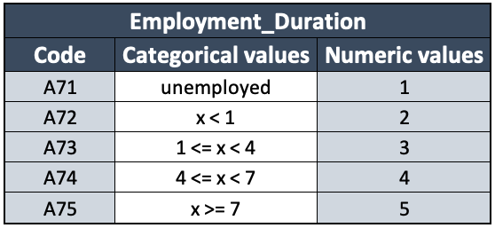

Then, we have defined a function that takes a table, a decoding matrix and a column name as input, and substitute every symbolic value in the column specified of the table with its respective categorical value. Finally, it returns the table with the decoded values in the column specified by the column name provided in input.

```r
# Define a new function
# Name: f_decode_values
# Input: tbl_data, df_decoding_matrix and col_name
# Process: Substitute the symbolic value in the specified column of the table with its respective categorical value
# Output: return the same table given as input, but with changed values in the specified column
f_decode_values <- function(tbl_data, df_decoding_matrix, col_name){

  # Cycle through each value of the specified column
  for (i in seq_along(tbl_data[[col_name]])){

    # Cycle through the decoding matrix to find what value matches the one in the data
    for (y in seq_along(df_decoding_matrix[,1])){

      # Check if the value in the decoding matrix matches the symbolic value in the data.
      # If so, change the symbolic value with the respective categorical value from the decoding matrix
      ifelse(tbl_data[[i,col_name]]==df_decoding_matrix[y,1], tbl_data[[i,col_name]] <- df_decoding_matrix[y,2],"")
    }
  }

  # Convert to factor type and add levels
  if(length(df_decoding_matrix[1,]) == 3){
    level_values <- df_decoding_matrix[,2]
    level_indexes <- df_decoding_matrix[,3]
    tbl_data[[col_name]] <- factor(tbl_data[[col_name]])
    levels(tbl_data[[col_name]]) <- level_values[level_indexes]
  }

  # Return the updated table
  return(tbl_data)
}
```

At this point, we have used the ‘f_decode_values’ function for each categorical column.

```r
# Cycle through all the categorical columns in the dataset
for(i in seq_along(v_cat_cols)){

  # Run the decoding function for each categorical column and save in place the result
  tbl_german_credit <- f_decode_values(data <- tbl_german_credit,
                                               df_decoding_matrix <- l_decod_matrices[[i]],
                                               col_name <- v_cat_cols[i])
}
```

As a result all the values are now understandable and ready to use

```r
# Dispaly the first 5 rows of the dataset
head(tbl_german_credit,5)
```

```
## # A tibble: 5 x 21
##   Account_Balance Duration_of_Cre… Status_Prev_Cre… Purpose Credit_Amount
##   <fct>                      <int> <fct>            <chr>           <int>
## 1 x < 0                          6 all credits at … radio/…          1169
## 2 x >=200                       48 delay in paying… radio/…          5951
## 3 0 <= x < 200                  12 all credits at … educat…          2096
## 4 x < 0                         42 delay in paying… furnit…          7882
## 5 x < 0                         24 existing credit… car (n…          4870
## # … with 16 more variables: Savings <fct>, Employment_Duration <fct>,
## #   Installment_Rate <int>, Sex_Marital_Status <chr>, Guarantors <fct>,
## #   Residence_Years <int>, Assets <fct>, Age <int>, Concurrent_Credits <chr>,
## #   Housing <fct>, Existing_Credits <int>, Job <fct>, N_Dependents <int>,
## #   Telephone <fct>, Foreign_Worker <fct>, Credit_Risk <int>
```

Next, to create a correlation matrix, we need a table containing only ordinal categorical, boolean and numeric variables. To do this we have defined a new function that takes the same inputs as the decoding function, but transform each symbolic value its respective ordinal position.

```r
# Define a new function
# Name: f_encode_num_values
# Input: tbl_data, df_decoding_matrix and col_name
# Process: Substitute the symbolic value in the specified column of the table with its respective categorical value
# Output: return the same table given as input, but with changed values in the specified column
f_encode_num_values <- function(tbl_data, df_decoding_matrix, col_name){
  # Check if the decoding matrix has 3 columns, if not the variable is not ordinal and do nothing
  if(length(df_decoding_matrix[1,]) == 3){

    # Create a new integer vector with of the same lenght of the specified column
    v_encoded_col <- vector(mode="integer", length <- length(tbl_data[[col_name]]))

    # Cycle through each value of the specified column
    for (i in seq_along(tbl_data[[col_name]])){

      # Cycle through each value of the decoding matrix to find what value matches the one in the data
      for (y in seq_along(df_decoding_matrix[,1])){

        # Check if the value in the decoding matrix matches the one in the data and substitute it with its
        # respective ordinal number if it does
        ifelse(tbl_data[[i,col_name]]==df_decoding_matrix[y,1], v_encoded_col[i] <- df_decoding_matrix[y,3],"")
      }
    }

    # Once all the symbolic values have been substituted with their respective ordinal values, update the
    # whole column with the updated values
    tbl_data[[col_name]] <- v_encoded_col
  }

  # Return the updated table
  return(tbl_data)
}
```

Similar to before, we applied the encode function to each ordinal and boolean categorical column in the dataset. Next, we have dropped all the non-ordinal and non-boolean columns, since they are not meaningful in a correlation plot.

```r
# Cycle through all the ordinal and boolean categorical columns in the dataset
for(i in seq_along(v_cat_cols)){

  # Run the encoding function for each column and save in place the result
  tbl_german_credit_num <- f_encode_num_values(data <- tbl_german_credit_num,
                                                         decoding_matrix <- l_decod_matrices[[i]],
                                                         col_name<-v_cat_cols[i])
}
# Drop the non-ordinal and non-boolean columns
tbl_german_credit_num <- tbl_german_credit_num %>%
  select(-Purpose, -Sex_Marital_Status, -Concurrent_Credits)
```

As a result of our transformations, we ended up with the following 2 tables:

```r
# Show unique values for each column
for(i in seq_along(tbl_german_credit)){
  cat("\n",colnames(tbl_german_credit)[i],"\n")
  print(head(unique(tbl_german_credit[[i]]),10))
}
```

```
##
##  Account_Balance
## [1] x < 0               x >=200             0 <= x < 200
## [4] no checking account
## Levels: x >=200 0 <= x < 200 x < 0 no checking account
##
##  Duration_of_Credit
##  [1]  6 48 12 42 24 36 30 15  9 10
##
##  Status_Prev_Credits
## [1] all credits at this bank paid
## [2] delay in paying off
## [3] existing credits paid
## [4] critical account/other credits existing (not at this bank)
## [5] no credits taken/all credits paid
## 5 Levels: no credits taken/all credits paid ... critical account/other credits existing (not at this bank)
##
##  Purpose
##  [1] "radio/television"    "education"           "furniture/equipment"
##  [4] "car (new)"           "car (used)"          "business"
##  [7] "domestic appliances" "repairs"             "other"
## [10] "retraining"
##
##  Credit_Amount
##  [1] 1169 5951 2096 7882 4870 9055 2835 6948 3059 5234
##
##  Savings
## [1] x >= 1000                 unkown/no savings account
## [3] 500 <= x < 1000           x < 100
## [5] 100 <= x < 500
## 5 Levels: 100 <= x < 500 500 <= x < 1000 ... x < 100
##
##  Employment_Duration
## [1] x >= 7     unemployed x < 1      1 <= x < 4 4 <= x < 7
## Levels: unemployed x < 1 1 <= x < 4 4 <= x < 7 x >= 7
##
##  Installment_Rate
## [1] 4 2 3 1
##
##  Sex_Marital_Status
```

[output cut: 32 more lines]

```
## 4 Levels: unemployed/unskilled - non-resident ... management / self-employed / highly qualified employee / officer
##
##  N_Dependents
## [1] 1 2
##
##  Telephone
## [1] yes no
## Levels: no yes
##
##  Foreign_Worker
## [1] no  yes
## Levels: yes no
##
##  Credit_Risk
## [1] 0 1
```

```r
# Show unique values for each column
for(i in seq_along(tbl_german_credit_num)){
  cat("\n",colnames(tbl_german_credit_num)[i],"\n")
  print(head(unique(tbl_german_credit_num[[i]]),10))
}
```

```
##
##  Account_Balance
## [1] 3 2 4 1
##
##  Duration_of_Credit
##  [1]  6 48 12 42 24 36 30 15  9 10
##
##  Status_Prev_Credits
## [1] 5 3 4 1 2
##
##  Credit_Amount
##  [1] 1169 5951 2096 7882 4870 9055 2835 6948 3059 5234
##
##  Savings
## [1] 1 2 4 5 3
##
##  Employment_Duration
## [1] 5 3 4 1 2
##
##  Installment_Rate
## [1] 4 2 3 1
##
##  Guarantors
## [1] 1 3 2
##
##  Residence_Years
## [1] 4 2 3 1
##
##  Assets
## [1] 4 3 1 2
##
##  Age
##  [1] 67 22 49 45 53 35 61 28 25 24
##
##  Housing
## [1] 2 3 1
##
##  Existing_Credits
## [1] 2 1 3 4
##
##  Job
## [1] 3 2 4 1
##
##  N_Dependents
## [1] 1 2
##
##  Telephone
## [1] 2 1
##
##  Foreign_Worker
## [1] 1 2
##
##  Credit_Risk
## [1] 0 1
```

[figure not shown]

## 2. Data Collection

The dataset was made public for research purposes vis-a-vis minimizing loss and maximizing profits on behalf of the bank from consumer credits.

## 3. Data Analysis

Since the objective is to predict the Credit Risk of a customer, using a correlation matrix, we were able to identify which ones have a strong linear correlation with consumers’ credit risk.

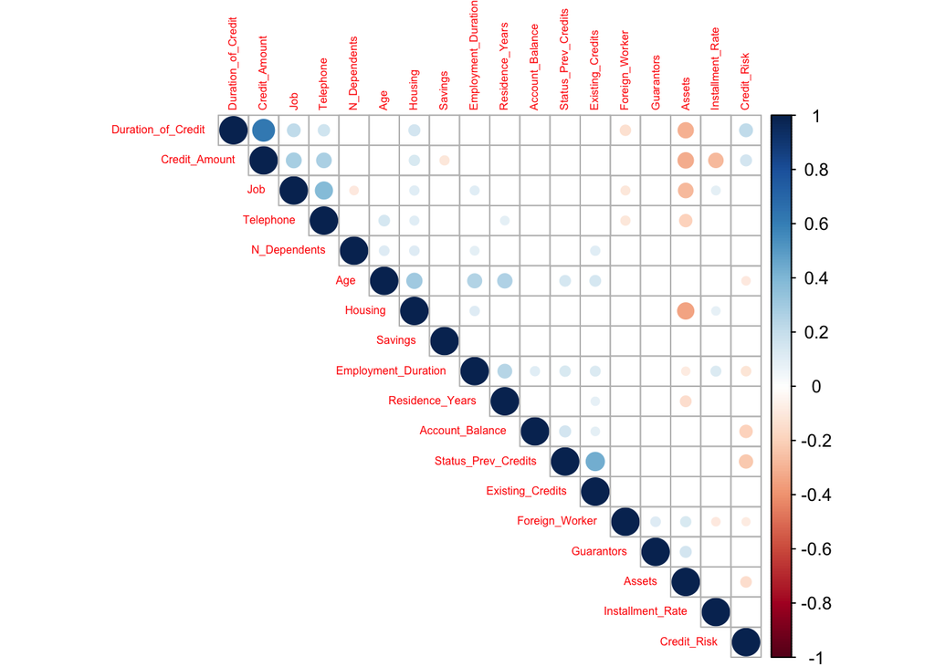

```r
m_corr <- rcorr(as.matrix(tbl_german_credit_num))
corrplot(m_corr$r, type="upper", order="hclust",
          p.mat=m_corr$P, sig.level=0.01, insig="blank",
         tl.offset = 0.50, tl.cex = 0.50)
```

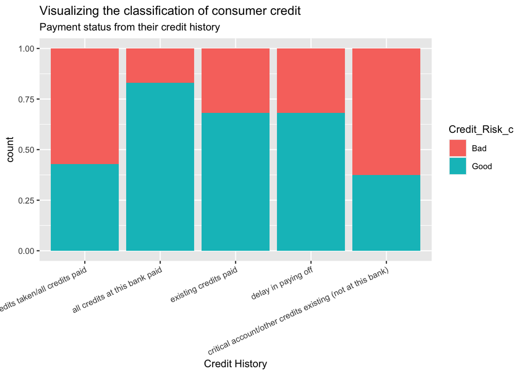

```r
# Adding a column for Credit Risk color
tbl_german_credit_graphs <- tbl_german_credit
tbl_german_credit_graphs$Credit_Risk_c <- ifelse(tbl_german_credit_graphs$Credit_Risk==0,"Good","Bad")
ggplot(data=tbl_german_credit_graphs, aes(x=Status_Prev_Credits, fill=Credit_Risk_c, position='fill')) +
    geom_bar(position='fill')+
    labs(title="Visualizing the classification of consumer credit",
       subtitle = "Payment status from their credit history") +
    theme(text = element_text(size=10),
        axis.text.x = element_text(angle=25, hjust=1))+
    xlab("Credit History")
```

Insights: Consumers’ credit history were segmented into five categories: “all paid”, “critical/other existing credits”,“delayed previously”, “existing paid”, and “no credits”. What piqued our interest from this plot is that there is a higher count of risky customers even if they have not taken any credits yet from the institution, along with customers with fully-paid credit history. This is a critical decision that should be concerned about since higher the credit risk, the more validation of uncertainty must be arranged between the stakeholders and the management. Also, this might raise a flag of how accurately they handle the selection process and assess loan grants. link: https://www.creditmanagement-tools.com/credit-risk-who-decide-c1-r1133.php

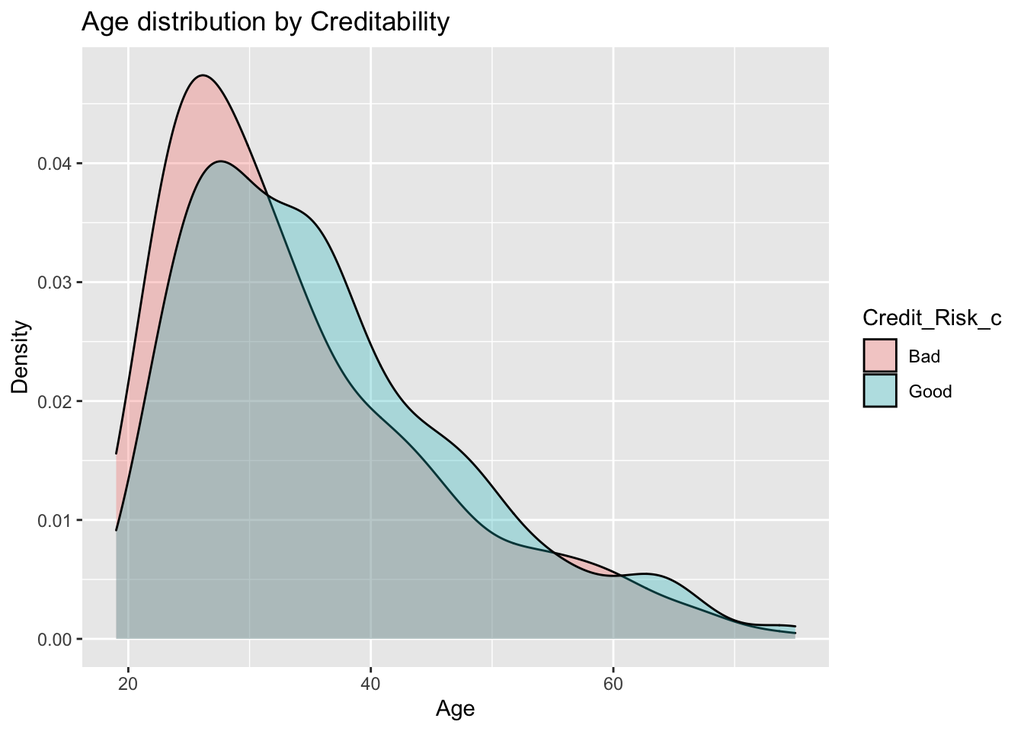

```r
ggplot(data=tbl_german_credit_graphs, aes(x=Age, fill=Credit_Risk_c))+
  geom_density(alpha=0.3)+
  labs(title="Age distribution by Creditability")+
  xlab("Age")+
  ylab("Density")
```

Insights: How risky are young borrowers? We can observe in this right-skewed plot that it is evident that younger people ages 25-30, at an average, avail more loan credit and are also tagged as much riskier. However, this can be also brought about by some lurking variables (e.g., the range of income, source of income (financial stability such as pension, other savings), etc). However, regardless of age, all individuals have distinct characteristics of being able to grant loan or not .

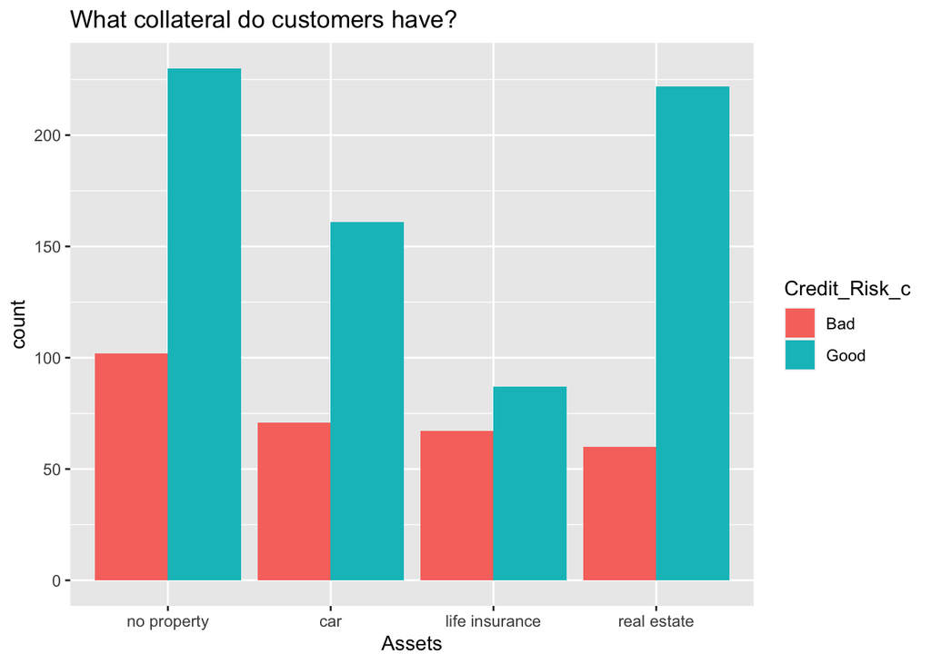

```r
ggplot(data=tbl_german_credit_graphs, aes(x=Assets, fill=Credit_Risk_c)) +
  geom_bar(position="dodge")+
  labs(title="What collateral do customers have?")
```

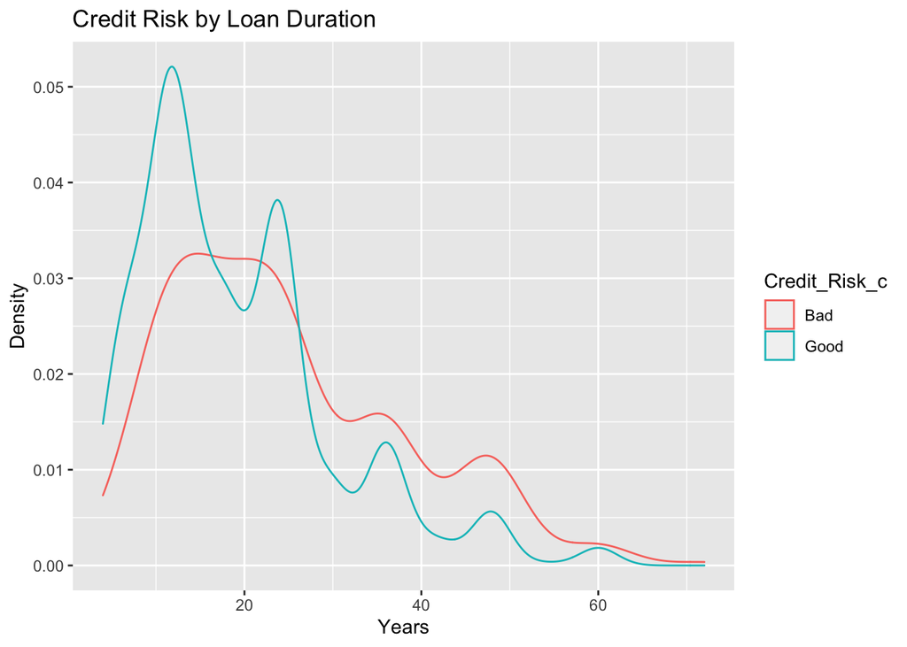

```r
ggplot(data=tbl_german_credit_graphs, aes(x=Duration_of_Credit, color=Credit_Risk_c)) +
  geom_density(position="identity")+
  labs(title="Credit Risk by Loan Duration")+
  xlab("Years")+
  ylab("Density")
```

## 3.1 Outliers Treatment

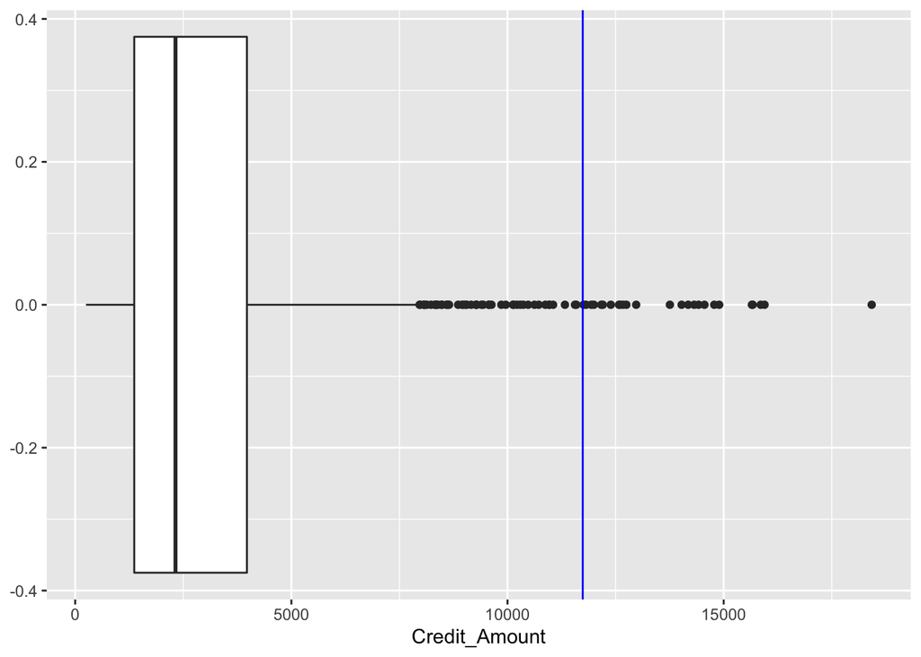

```r
ggplot(data=tbl_german_credit_graphs, aes(x=Credit_Amount)) +
  geom_boxplot()+
  geom_vline(xintercept=(sd(tbl_german_credit$Credit_Amount)*3) + mean(tbl_german_credit$Credit_Amount), color='Blue')
```

```r
#Finding std of Credit_Amount
sd_credit_amount <- sd(tbl_german_credit$Credit_Amount)
#Check if the top outlier is more than 3 standard deviations
max_sd_credit_amount <- (max(tbl_german_credit$Credit_Amount)-mean(tbl_german_credit$Credit_Amount)) / sd_credit_amount
cat("Now, the biggest outlier for Credit Amount is", max_sd_credit_amount, "stds away from the mean")
```

```
## Now, the biggest outlier for Credit Amount is 5.368103 stds away from the mean
```

```r
tbl_german_credit <- tbl_german_credit %>%
  filter(Credit_Amount < (sd_credit_amount*3) + mean(tbl_german_credit$Credit_Amount))
```

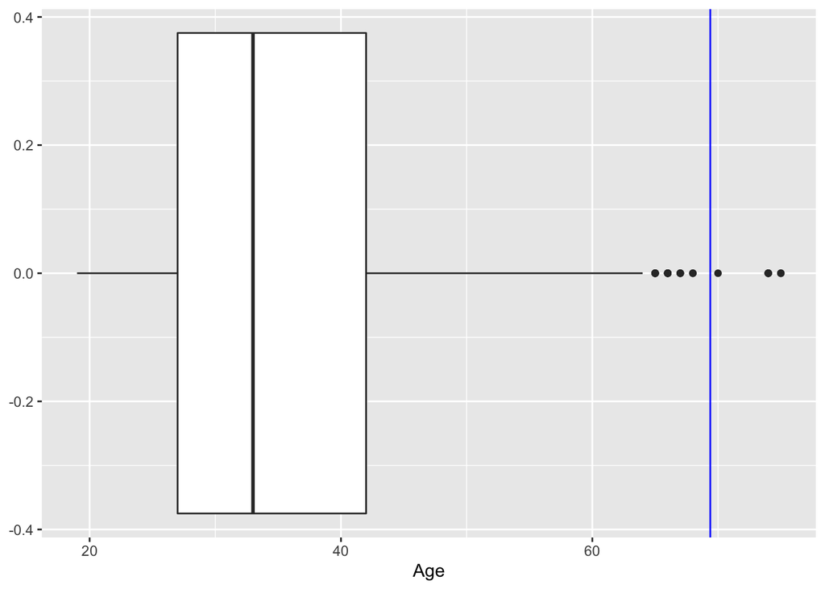

```r
ggplot(data=tbl_german_credit, aes(x=Age)) +
  geom_boxplot() +
  geom_vline(xintercept=(sd(tbl_german_credit$Age)*3) + mean(tbl_german_credit$Age), color='Blue')
```

```r
#Finding std of Age
sd_credit_age <- sd(tbl_german_credit$Age)
#Check if the top outlier is more than 3 standard deviations
max(tbl_german_credit$Credit_Amount) / sd_credit_amount
```

```
## [1] 4.105944
```

In this boxplot, showing the distribution of age. As before, we decided to dropall the outliers lying more than 3 standard deviations away from the mean.

```r
#Finding std of Credit_Amount
sd_credit_age <- sd(tbl_german_credit$Age)
#Check if the top outlier is more than 3 standard deviations
max_sd_credit_age <- (max(tbl_german_credit$Age)-mean(tbl_german_credit$Age)) / sd_credit_age
cat("The biggest outlier for Age is", max_sd_credit_age, "stds away from the mean")
```

```
## The biggest outlier for Age is 3.496439 stds away from the mean
```

```r
tbl_german_credit <- tbl_german_credit %>%
  filter(Age < (sd_credit_age*3) + mean(tbl_german_credit$Age))
```

## Conclusions

The visualizations and the correlation matrix show some substantial relationships between many different variables and the dependent variable “Credit_Risk”. With all these, we can confidently conclude that the dataset has sufficient information to create a model predicting the credit worthiness of potential customers with reliable accuracy.

# Modelling and Communication

### Training and Testing Dataset

We randomly split the dataset into a particular ratio where 80% will be the training set mainly for building the predictive model whereas 20% will be the testing set specific for evaluating the model. In this way, the model can be trained in a larger scale in order to adapt to possible exposure of real and random effects[1] and 80/20 is considered a fair split given the number of observations that we have[2]. [source: [1] https://towardsdatascience.com/train-test-split-c3eed34f763b,[2] https://stackoverflow.com/questions/13610074/is-there-a-rule-of-thumb-for-how-to-divide-a-dataset-into-training-and-validation]

```r
# Split dataset in train (80%) and test (20%)
set.seed(150)
input_sample <- sort(sample(nrow(tbl_german_credit), nrow(tbl_german_credit)*.8))
train <- tbl_german_credit[input_sample, ]
test <- tbl_german_credit[-input_sample, ]
```

Using `dim()` function, we can print the dimensions of all variables and notice the 80%-20% split of the dataset:

```r
dim(train)
```

```
## [1] 774  21
```

```r
dim(test)
```

```
## [1] 194  21
```

### Using logit model

#### Full Model

We ran a basic logistic regression model, named `model_f`, containing all $\beta$ parameters in the dataset to know which necessary variables should be retained in the following steps. The code below estimates a logit model using `glm()` function. Take note that all categorical variables are already set up as factors so that the model can treat them as one.

```r
# Train full model
model_f <- glm(formula = Credit_Risk ~ ., data = train, family = binomial(link="logit"))

summary(model_f)
```

```
##
## Call:
## glm(formula = Credit_Risk ~ ., family = binomial(link = "logit"),
##     data = train)
##
## Deviance Residuals:
##     Min       1Q   Median       3Q      Max
## -1.9685  -0.6854  -0.3692   0.7095   2.6521
##
## Coefficients:
##                                                                                 Estimate
## (Intercept)                                                                   -3.542e+00
## Account_Balance0 <= x < 200                                                   -1.336e+00
## Account_Balancex < 0                                                           3.239e-01
## Account_Balanceno checking account                                            -5.094e-01
## Duration_of_Credit                                                             3.266e-02
## Status_Prev_Creditsall credits at this bank paid                              -1.398e+00
## Status_Prev_Creditsexisting credits paid                                      -6.030e-01
## Status_Prev_Creditsdelay in paying off                                        -6.312e-01
## Status_Prev_Creditscritical account/other credits existing (not at this bank)  5.808e-03
## Purposecar (new)                                                               8.100e-01
## Purposecar (used)                                                             -7.925e-01
## Purposedomestic appliances                                                     3.522e-01
## Purposeeducation                                                               1.134e+00
## Purposefurniture/equipment                                                     3.818e-02
## Purposeother                                                                  -2.178e+00
## Purposeradio/television                                                       -7.755e-02
## Purposerepairs                                                                 9.994e-02
## Purposeretraining                                                             -4.691e-01
## Credit_Amount                                                                  1.314e-04
## Savings500 <= x < 1000                                                        -4.134e-01
## Savingsx >= 1000                                                              -6.930e-01
## Savingsunkown/no savings account                                               2.280e-01
## Savingsx < 100                                                                -1.463e+00
## Employment_Durationx < 1                                                      -5.506e-01
## Employment_Duration1 <= x < 4                                                  9.262e-01
## Employment_Duration4 <= x < 7                                                  3.106e-01
## Employment_Durationx >= 7                                                     -1.990e-02
## Installment_Rate                                                               4.268e-01
## Sex_Marital_Statusmale divorced/separated                                      5.002e-01
```

[output cut: 215 more lines]

```
## Jobskilled employee / official
## Jobmanagement / self-employed / highly qualified employee / officer
## N_Dependents
## Telephoneyes
## Foreign_Workerno                                                              *
## ---
## Signif. codes:  0 '***' 0.001 '**' 0.01 '*' 0.05 '.' 0.1 ' ' 1
##
## (Dispersion parameter for binomial family taken to be 1)
##
##     Null deviance: 951.97  on 773  degrees of freedom
## Residual deviance: 685.70  on 725  degrees of freedom
## AIC: 783.7
##
## Number of Fisher Scoring iterations: 6
```

This model shows many statistically insignificant variables, for example N_Depedents and Telephone, have p-values greater than 0.05, making them unrelevant for the scope of our analysis. In the next steps we are going to select a model using the most useful and statistically significant variables.

#### Choosing the number of independent variables

As with any predictive modeling, we can not simply conclude that this model would be sufficient enough to explain that the variables are actually contributing to the credit risk of a customer. Variables with p-value greater than the significant level of 5% prompt us to perform another model, keeping only the variables that are found statistically significant with the dependent variable.

Apart from looking at the p-values, another way to select variables that seem a better fit to the model is by using a `random forest algorithm` where `repeated cross-validation method` is done to test the variables in different subsets.

```r
# Convert table to data.frame
train <- data.frame(train)

# Convert Credit_Risk to column to factor
train[,21] <- as_factor(train[,21])

# Set up the random forest algorithm using a repteaded cross validation made of 5 subsets and repeat the whole process 10 times with different subsets
train_ctrl <- rfeControl(functions = rfFuncs, method="repeatedcv", number=5, repeats = 10,verbose=FALSE)

# Run the model
rf_result <- rfe(x = train[,1:20], y = train[,21], sizes = c(1:20), rfeControl = train_ctrl)

# Average results by variable
rankings <- rf_result$variables %>%
  group_by(var) %>%
  summarise(Overall = mean(Overall)) %>%
  arrange(desc(Overall))
```

[figure not shown]

```r
# Plot the results
ggplot(data=rf_result, aes(x=Variables, y=Kappa)) +
  geom_line() +
  geom_hline(yintercept=0.755, color="red")+
  labs(title="Figure 1: Accuracy by Number of Variable Selection")+
  xlab("Number of Variables")
```

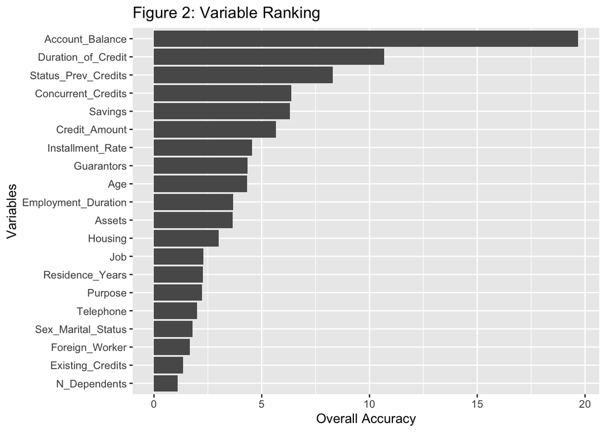

```r
ggplot(data=rankings, aes(y=reorder(var,Overall),x=Overall)) +
  geom_bar(stat='identity')+
  labs(title="Figure 2: Variable Ranking")+
  xlab("Overall Accuracy")+
  ylab("Variables")
```

`Figure 2` allows us to know which specific variables should be plugged into the model where variables were ranked by its overall relevance. With this, we can now proceed to building the reduced model.

#### Reduced Model

```r
# reduced model
model_r <- glm(formula = Credit_Risk ~ Credit_Amount  + Installment_Rate + Duration_of_Credit + Age + Savings + Account_Balance + Status_Prev_Credits + Purpose + Guarantors + Concurrent_Credits + Employment_Duration + Assets, data = train, family = binomial(link="logit"))

summary(model_r)
```

```
##
## Call:
## glm(formula = Credit_Risk ~ Credit_Amount + Installment_Rate +
##     Duration_of_Credit + Age + Savings + Account_Balance + Status_Prev_Credits +
##     Purpose + Guarantors + Concurrent_Credits + Employment_Duration +
##     Assets, family = binomial(link = "logit"), data = train)
##
## Deviance Residuals:
##     Min       1Q   Median       3Q      Max
## -2.1964  -0.7022  -0.4045   0.7839   2.5564
##
## Coefficients:
##                                                                                 Estimate
## (Intercept)                                                                    0.2652719
## Credit_Amount                                                                  0.0001043
## Installment_Rate                                                               0.3526470
## Duration_of_Credit                                                             0.0340693
## Age                                                                           -0.0193527
## Savings500 <= x < 1000                                                        -0.5574699
## Savingsx >= 1000                                                              -0.7689858
## Savingsunkown/no savings account                                               0.1554059
## Savingsx < 100                                                                -1.4590866
## Account_Balance0 <= x < 200                                                   -1.3364153
## Account_Balancex < 0                                                           0.3518857
## Account_Balanceno checking account                                            -0.6136611
## Status_Prev_Creditsall credits at this bank paid                              -1.3378510
## Status_Prev_Creditsexisting credits paid                                      -0.5576042
## Status_Prev_Creditsdelay in paying off                                        -0.6251238
## Status_Prev_Creditscritical account/other credits existing (not at this bank) -0.0099701
## Purposecar (new)                                                               0.7368669
## Purposecar (used)                                                             -0.7851126
## Purposedomestic appliances                                                     0.3226776
## Purposeeducation                                                               1.1689134
## Purposefurniture/equipment                                                     0.1124087
## Purposeother                                                                  -2.5270263
## Purposeradio/television                                                       -0.0799813
## Purposerepairs                                                                -0.0430666
## Purposeretraining                                                             -0.3378849
## Guarantorsco-applicant                                                        -1.5071410
## Guarantorsguarantor                                                           -0.8398602
```

[output cut: 152 more lines]

```
## Employment_Duration4 <= x < 7
## Employment_Durationx >= 7
## Assetscar
## Assetslife insurance
## Assetsreal estate
## ---
## Signif. codes:  0 '***' 0.001 '**' 0.01 '*' 0.05 '.' 0.1 ' ' 1
##
## (Dispersion parameter for binomial family taken to be 1)
##
##     Null deviance: 951.97  on 773  degrees of freedom
## Residual deviance: 710.81  on 738  degrees of freedom
## AIC: 782.81
##
## Number of Fisher Scoring iterations: 5
```

#### Making Predictions

We’ll now make predictions using the testing dataset to evaluate the regression model that was made. The procedure is as follows:

### Full Model

```r
#prediction method to find out predictions from the logistic regression made
model_f_pred <- predict(model_f, test, type="response")

#displays the probability output of the first 10 rows of the dataset
head(model_f_pred, 10)
```

```
##          1          2          3          4          5          6          7
## 0.26482513 0.24984257 0.65885506 0.03274646 0.05221078 0.08762005 0.03718968
##          8          9         10
## 0.10904986 0.40881910 0.18564963
```

```r
#decision rule assignment
model_f_dr <- ifelse(model_f_pred > 0.5, 1,0)
```

```r
#displays the confusion matrix  as  an output
table(model_f_dr, test$Credit_Risk)
```

```
##
## model_f_dr   0   1
##          0 125  25
##          1  23  21
```

The confusion matrix shows the frequencies of true positives (0,0), false positives (0,1), false negatives (1,0), true negatives (1,1) of the model prediction. Where a false positive corresponds to a type 1 error and a false negative corresponds to a type 2 error. In our case, the models makes 25 type 1 errors, predicting 25 ‘Good’ credit risks when in fact, should be classified as ‘Bad’.

### Assessing the model accuracy

This step will be measured by getting the mean of proportion of correctly classified observations.

```r
# Accuracy
mean(model_f_dr == test$Credit_Risk)
```

```
## [1] 0.7525773
```

```r
#prediction method to find out predictions from the logistic regression made
model_r_pred <- predict(model_r, test, type="response")

#displays the probability output of the first 10 rows of the dataset
head(model_r_pred, 10)
```

```
##          1          2          3          4          5          6          7
## 0.37054203 0.32357203 0.48779023 0.03155006 0.08027157 0.09450926 0.20239505
##          8          9         10
## 0.04448761 0.55347257 0.15884090
```

```r
#decision rule assignment
model_r_dr <- ifelse(model_r_pred > 0.6, 1,0)
```

```r
#displays the confusion matrix  as  an output
table(model_r_dr, test$Credit_Risk)
```

```
##
## model_r_dr   0   1
##          0 137  28
##          1  11  18
```

Similar as above, the reduced logistic regression model commits 28 type 1 errors and 11 type 2 errors.

```r
# Accuracy
mean(model_r_dr == test$Credit_Risk)
```

```
## [1] 0.7989691
```

As for the reduced model, it achieved a classification prediction accuracy of 80%, which indicates a good rate, having a classification error of 20%.

#### ROC Curves

TPR: True Positive Rate FPR: False Positive Rate

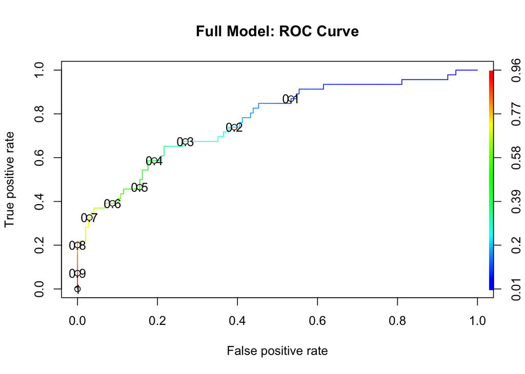

```r
library(ROCR)
#prediction for full model
roc_full <- model_f_pred #create a variable
roc_prediction_f <- prediction(roc_full, test$Credit_Risk) #cross-validation of the 2 vectors for full model
roc_performance_f <- ROCR::performance(roc_prediction_f, "tpr", "fpr") #Y and Yhat are rvs representing  the class and  the prediction for randomly drawn sample in the full model
#plotting  the curve
plot(roc_performance_f, colorize = T, print.cutoffs.at=seq(0.1, by= (0.1)),
       main = "Full Model: ROC Curve")
```

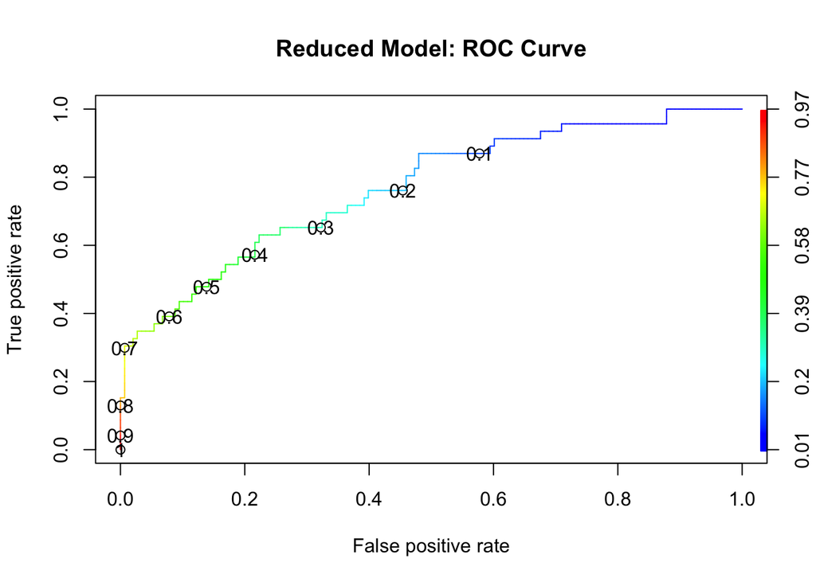

```r
#prediction for reduced model
roc_reduced <- model_r_pred
roc_prediction_r <- prediction(roc_reduced, test$Credit_Risk) #cross-validation of the 2 vectors for full model
roc_performance_r <- ROCR::performance(roc_prediction_r, "tpr", "fpr")#Y and Yhat are rvs representing  the class and  the prediction for randomly  drawn sample in the  reduced model
#plotting the curve
plot(roc_performance_r, colorize = T, print.cutoffs.at=seq(0.1, by= (0.1)),
       main = "Reduced Model: ROC Curve")
```

The ROC curves show all the possible combinations of True Positive rates and False Positive rates.

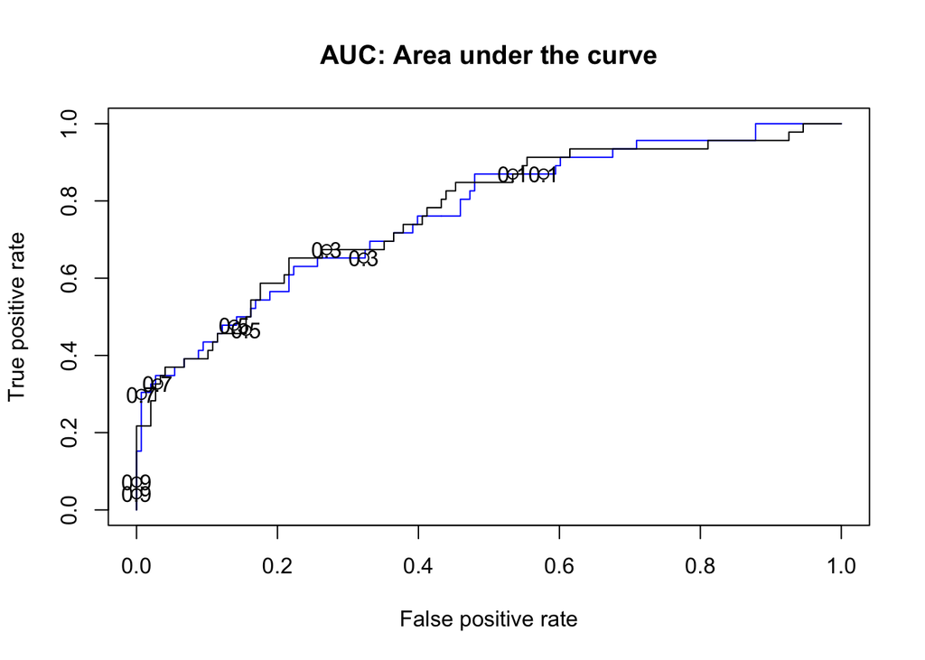

```
## integer(0)
```

```r
#plotting the curve of the two models
plot(roc_performance_r, col = "blue", print.cutoffs.at=seq(0.1, by= (0.20)),
     main="AUC: Area under the curve")+
plot(roc_performance_f, add = TRUE, print.cutoffs.at=seq(0.1, by= (0.20)))
```

Plotting together the predictions of the full and reduced models we can conclude that there is not any statistical difference between the 2. Therefore, the reduced model with less variables is preferred because it provide the same information with less value and it is also less likely to overfit. source:https://people.duke.edu/~mababyak/papers/babyakregression.pdf

### AUC: Area under the curve

```r
aucfull <- ROCR::performance(roc_prediction_f, measure = "auc",print.auc = TRUE)
aucreduced <- ROCR::performance(roc_prediction_r, measure = "auc",print.auc = TRUE)
aucfull@y.values #outputs the prediction rate of full model
```

```
## [[1]]
## [1] 0.7686545
```

```r
aucreduced@y.values #outputs the prediction rate of reduced model
```

```
## [[1]]
## [1] 0.7671857
```

As expected, the 2 models provide a similar accuracy and we can reinforce our decision of preferring the reduced one.

# Results and Conclusion

Stage 1: Built a Logistic Regression Model using all the variables as a baseline model.

Stage 2: Ran a random forest algorithm to rank the most relevant variables and choose the number of independent variables

Stage 3: Used the information obtained in Stage 2 to build a Reduced Model, using 12 variables.

Stage 4: Compared the 2 models to assess which has the best performance

Stage 5: The reduced model actually performs better than the full model having lower AIC (explaining that it has lesser errors and a better fit for the data) source: https://www.scribbr.com/statistics/akaike-information-criterion/. Also, having a statistical proof that the variables used were actually relevant.